# Analysis of the trajectories of the harvesters using HMM

In this document I will present some results and interpretations of the analysis of the spatial trajectories of the harvesters using Hidden Markov Models (HMM).

### 0. Introduction to HMM

Here we will use the *movehmm* library (ref*) to i) fit the most likely HMM to the harvester movement data and ii) describe the different states, the sequence of states and the difference between farms.

### 1. Fitting of HMM

#### 1.1. Preparation of data

We loaded *ggplot2*, *dplyr*, *tidyverse* and *movehmm* libraries. We then loaded the data of the trajectories and did some punctual modifications to it. We have in total 12 trajectories, with ($x, y$) coordinates:

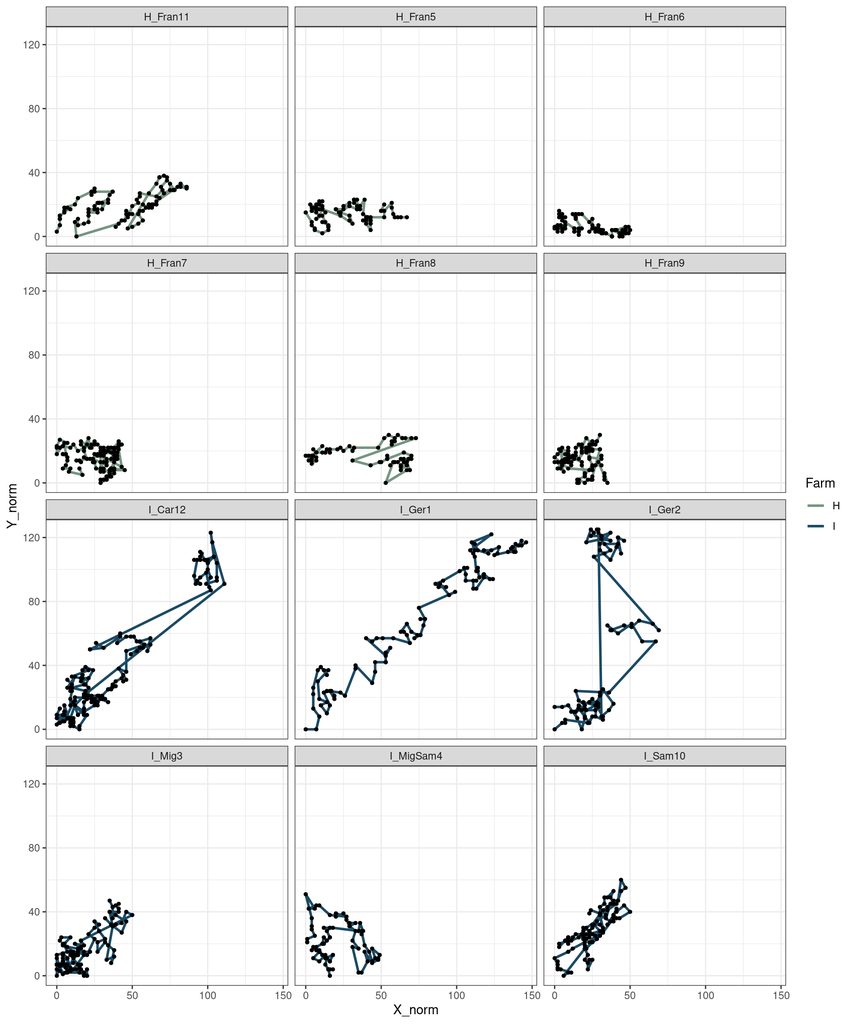

12 trajectories of harvesters. The green line represent the Finca Hamburgo (H) and the blue line the Finca Irlanda (I)

In this approach we made no difference between the two farms (but will use it a posteriori). A first assumption for the analysis is made: we took these time irregular trajectories (where each point represents one different tree, but where the time between two trees is variable) and will treat them as a regular trajectories. We only want to analyze if the movement of the workers across the plots has different states (taking all the trajectories into account). This also assumes that the underneath pattern of trees is relatively homogeneous and is not the main determinant of the trajectories. We convert this data base into a movehmm object:

```
## Movement data for 12 tracks:
## I_Ger1 -- 100 observations
## I_Ger2 -- 80 observations
## I_Mig3 -- 107 observations
## I_MigSam4 -- 76 observations
## H_Fran5 -- 77 observations
## H_Fran6 -- 70 observations
## H_Fran7 -- 115 observations
## H_Fran8 -- 63 observations
## H_Fran9 -- 97 observations
## I_Sam10 -- 104 observations
## H_Fran11 -- 88 observations
## I_Car12 -- 158 observations
## No covariates.
```

```r
head(dataCosecha)
```

|  | ID | step | angle | x | y |
| --- | --- | --- | --- | --- | --- |
| 1 | I_Ger1 | 3.605551 | NA | 146 | 117 |
| 2 | I_Ger1 | 3.000000 | -2.158799 | 143 | 115 |
| 3 | I_Ger1 | 3.605551 | 2.553590 | 143 | 118 |
| 4 | I_Ger1 | 2.236068 | -1.446441 | 141 | 115 |
| 5 | I_Ger1 | 5.000000 | 2.034444 | 139 | 116 |
| 6 | I_Ger1 | 3.605551 | -2.158799 | 139 | 111 |

The distance step and the relative angle is calculated for each of the 12 trajectories. We show the histograms of both the steps and the angles.

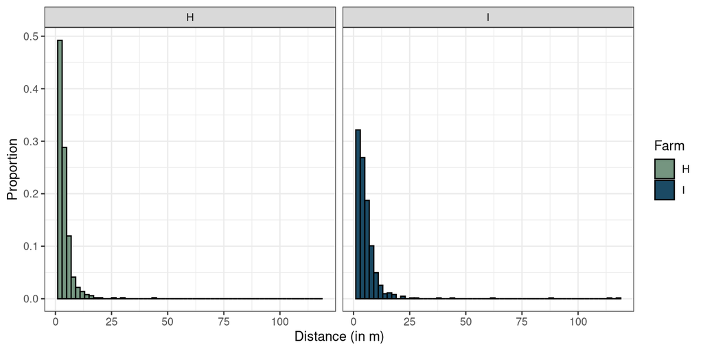

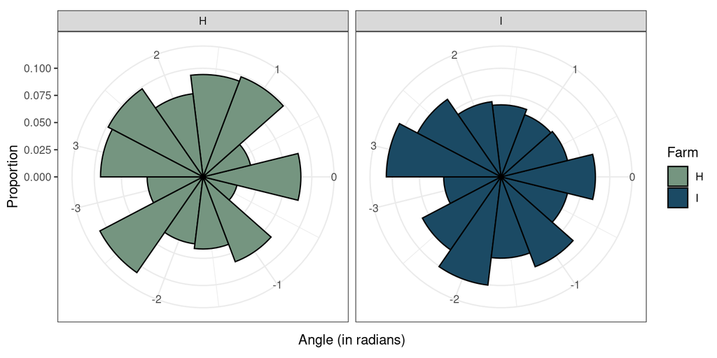

Now, for the following analysis, we will only use the step distance and treat both farms as one. We decide to not include the angles to simplify the analysis and interpretation. In this sense, the input for the analysis is the following histogram:

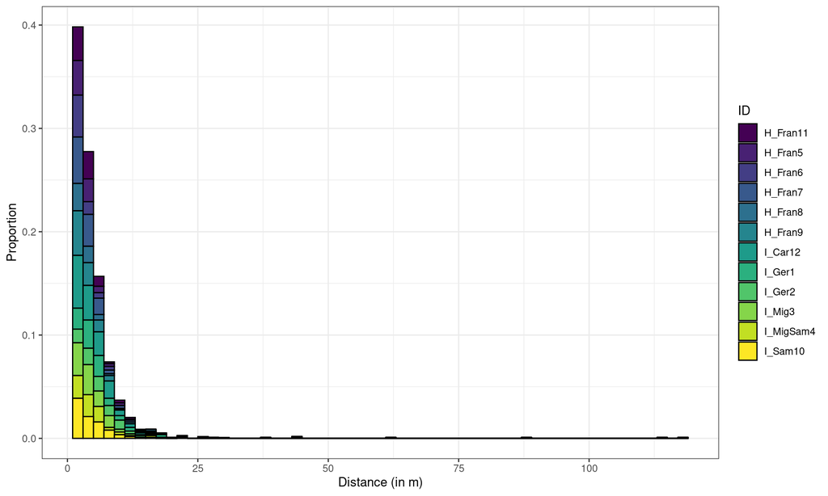

### I.2. Fitting of the data

The fitting algorithm (ref*) of the movehmm library uses:

1. a number of states. Here we will use 2.
2. a defined family of distributions (gamma, lnorm, or weibull). Here we will try to fit each of the families.
3. prior parameters for each of the distrubioon of each state
4. The observations (step-lengths) (the data of harvesters)

And it extracts the most likely 2-state-distributions with its respective parameters (within the predefined family of distributions) that fit the data. During the fitting process, the algorithm uses the maximum-log likelihood and the *forward algoritm (ref) using the prior parameters. In this sense, the correct choice of these parameters is crucial causes the algorithm can reach local maximums and not the global maximum.

| value | gamma.mean | gamma.sd | weibull.shape | weibull.scale | lnorm.location | lnorm.scale |
| --- | --- | --- | --- | --- | --- | --- |
| min | 0.1 | 0.1 | 0.0 | 0.1 | -1 | 0.001 |
| max | 20.0 | 20.0 | 2.7 | 15.0 | 20 | 3.000 |

Some results registered combinations where one of the distributions had zero variance.We decided to remove those cases has they did not make biological sense.

| model | prior_par0_st1 | prior_par0_st2 | prior_par1_st1 | prior_par1_st2 | minNegLike | AIC_model | st1_par0 | st1_par1 | st2_par0 | st2_par1 | conteo | contador |
| --- | --- | --- | --- | --- | --- | --- | --- | --- | --- | --- | --- | --- |
| weibull | 2.11 | 2.44 | 14.72 | 0.56 | 2944.47 | 5902.95 | 0.00 | 0.00 | 1.22 | 5.57 | 1 | 1 |
| weibull | 0.06 | 2.19 | 10.43 | 14.56 | 2944.47 | 5902.95 | 1.22 | 5.57 | 0.00 | 0.00 | 1 | 2 |
| weibull | 1.95 | 1.11 | 1.15 | 10.76 | 2944.47 | 5902.95 | 1.22 | 5.57 | 10.62 | 0.00 | 1 | 3 |
| weibull | 2.45 | 1.96 | 0.43 | 14.68 | 2944.47 | 5902.95 | 1.22 | 5.57 | 0.00 | 0.00 | 1 | 4 |
| weibull | 1.09 | 2.05 | 9.42 | 14.05 | 2944.47 | 5902.95 | 19.28 | 0.00 | 1.22 | 5.57 | 1 | 5 |
| weibull | 1.81 | 1.15 | 14.07 | 8.39 | 2944.47 | 5902.95 | 1.22 | 5.57 | 21.52 | 0.00 | 1 | 6 |

We then plot the min negative log of the likelihood without these outliers

```r
DF_1000_SIN <- DF_TOTAL_1000 %>%
  filter(st1_par1 >0.00001 & st2_par1 >0.00001)
```

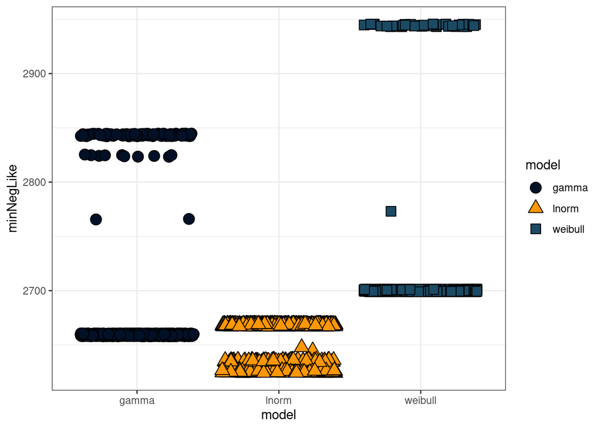

We take for each family of distributions the minimini likeloojd

```r
DF_TOTAL_MIN <- DF_1000_SIN %>%
  group_by(model)%>%
  filter(AIC_model == min(AIC_model)) %>%
  group_by(model, AIC_model) %>%
  mutate(conteo = 1)%>%
  mutate(contador= cumsum(conteo))%>%
  filter(contador ==1)

# DF_1000_OUTLIERS<- DF_1000_OUTLIERS %>%
#   mutate(contador = 1)%>%
#   group_by(model) %>%
#   mutate(countModel = cumsum(contador))
#
# OUTLIERS_EX <- DF_1000_OUTLIERS %>%
#   filter(countModel == 1)
```

```r
modelos_p <- list("gamma" = 0,
     "weibull" = 0,  ##segun el articulo
     "lnorm" =  0)

for (i in seq(1,dim(DF_TOTAL_MIN)[1],1)){
  par0_p <- as.numeric(c(DF_TOTAL_MIN$prior_par0_st1[i], DF_TOTAL_MIN$prior_par0_st2[i]))
  par1_p <- as.numeric(c(DF_TOTAL_MIN$prior_par1_st1[i], DF_TOTAL_MIN$prior_par1_st2[i]))
  stepPar0_p <- c(par0_p, par1_p)
  print(stepPar0_p)
  #op1
  m_cosecha_p<- fitHMM(data = dataCosecha, nbStates = 2 , stepPar0 = stepPar0_p, angleDist = "none", stepDist = as.character(DF_TOTAL_MIN$model[i]))
  modelos_p[[as.character(DF_TOTAL_MIN$model[i])]] <- m_cosecha_p
}
```

```
## [1]  2.2  0.8  5.1 13.2
## [1] 1.94 5.61 6.46 1.15
## [1] -0.54 -0.71  1.11  1.31
```

```
## Decoding states sequence... DONE
```

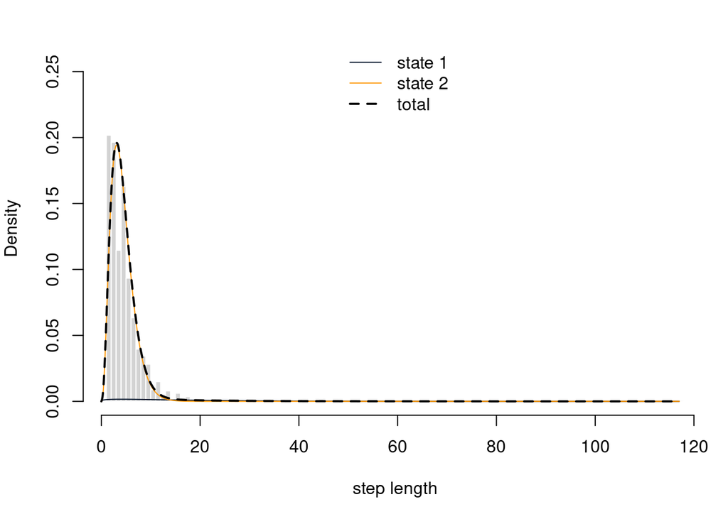

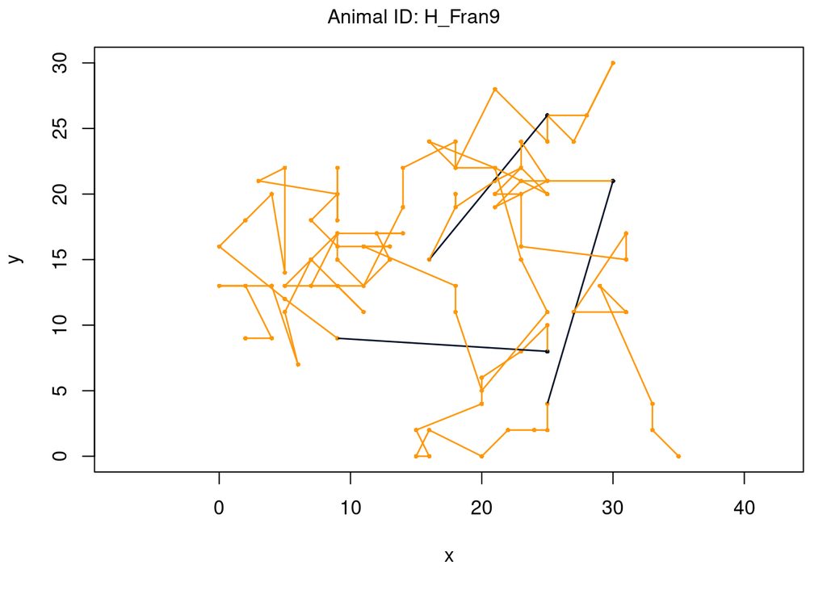

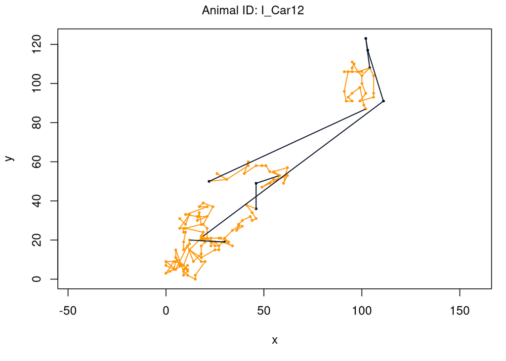

```r
plot(modelos_p$gamma, animals = c("I_Car12", "H_Fran9"), ask = FALSE, plotTracks = TRUE, breaks = 100, col = groupColors2, lwd=3.0)
```

```
## Decoding states sequence... DONE
```

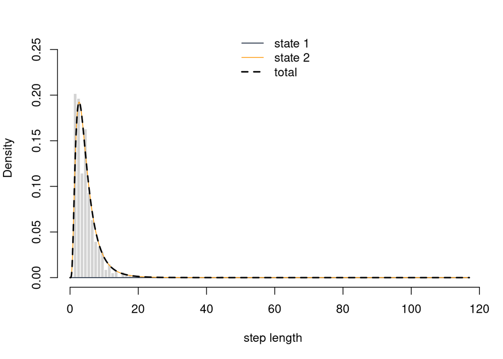

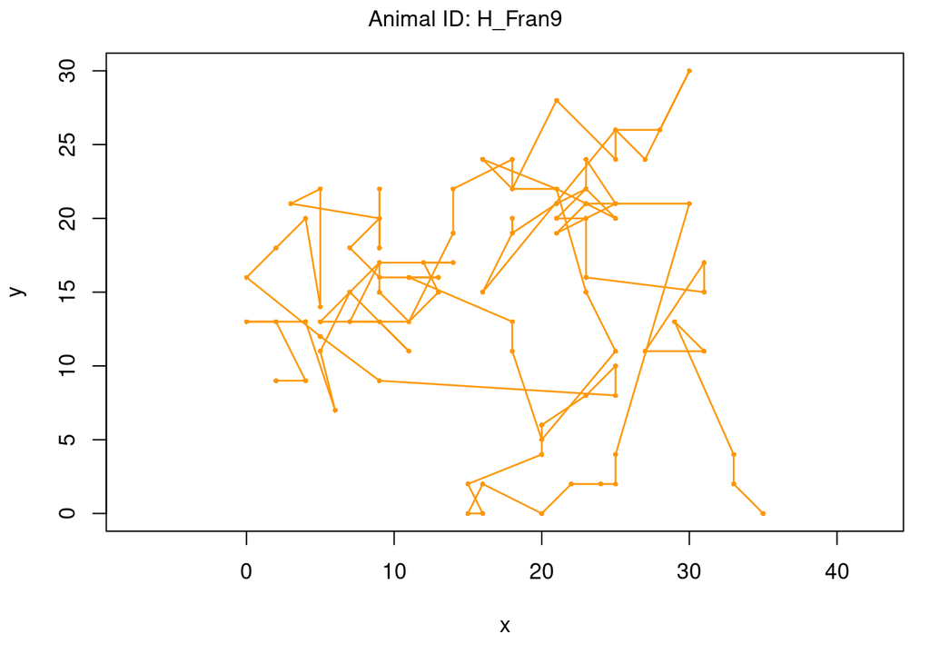

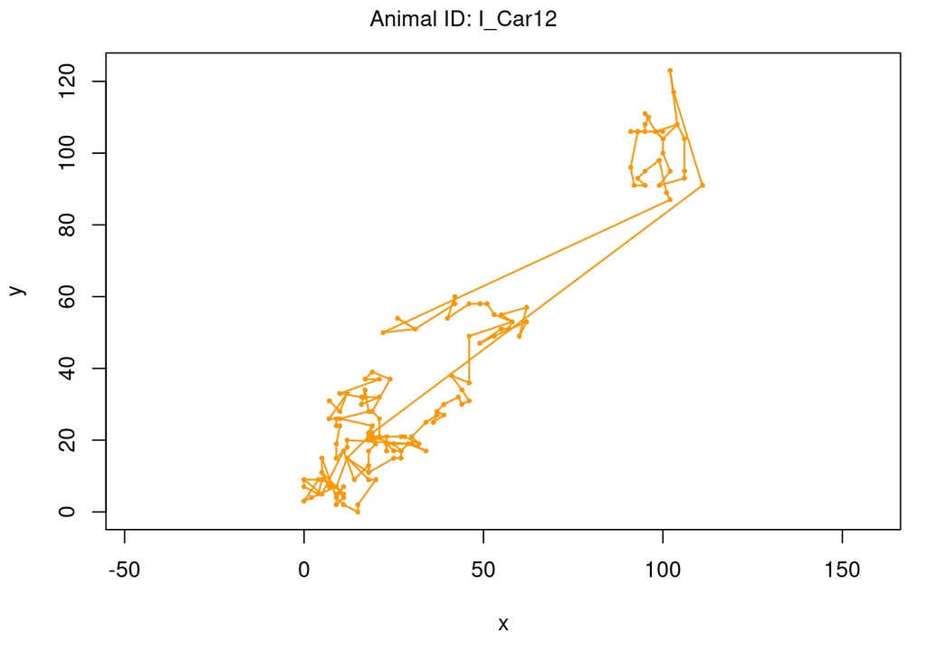

```r
plot(modelos_p$lnorm, animals = c("I_Car12", "H_Fran9"), ask = FALSE, plotTracks = TRUE, breaks = 100, col = groupColors2, lwd=3.0)
```

```
## Decoding states sequence... DONE
```

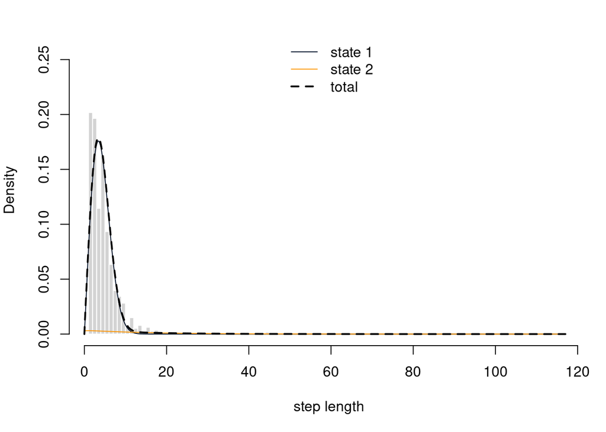

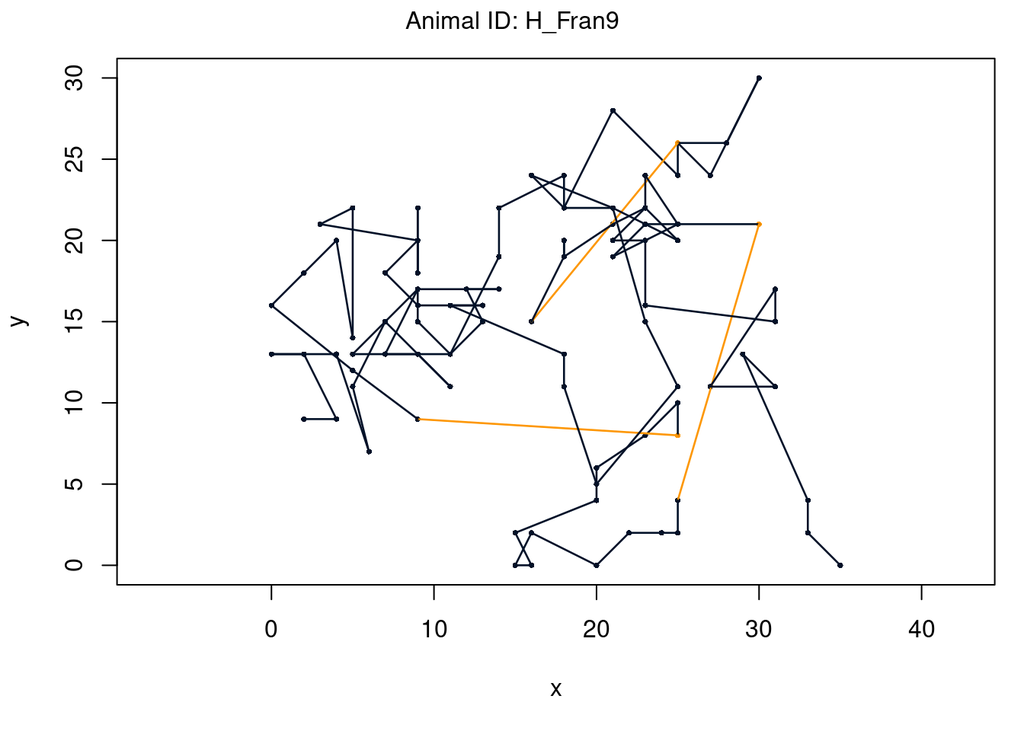

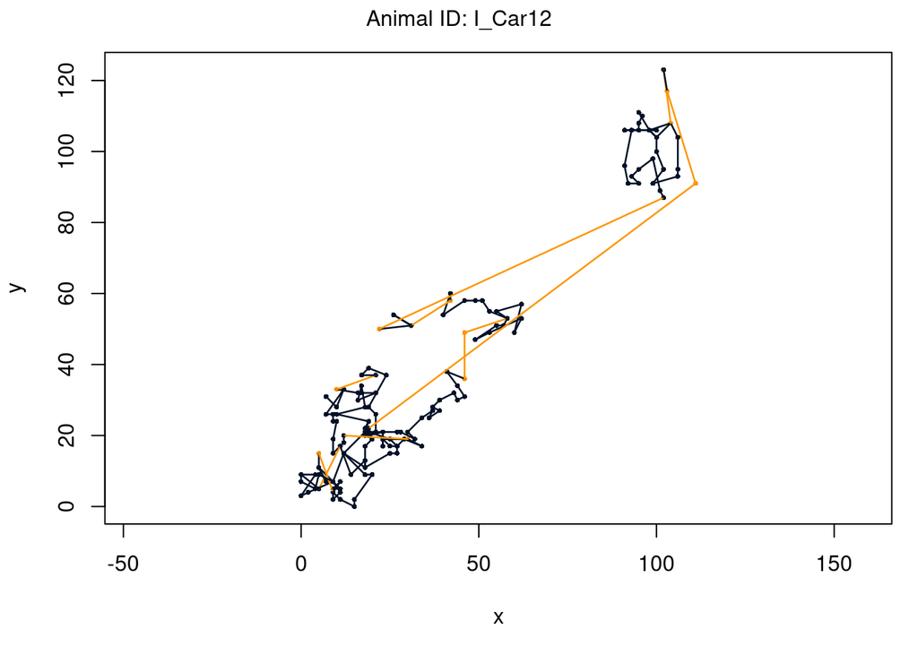

```r
plot(modelos_p$weibull, animals = c("I_Car12", "H_Fran9"), ask = FALSE, plotTracks = TRUE, breaks = 100, col = groupColors2, lwd=3.0)
```